# Ejercicios de Variable Aleatoria Gaussiana

Análisis Estadístico y Probabilístico

Noe Ulises Machaca Chambilla

27 de April, 2026

## Introducción

La distribución normal o Gaussiana es fundamental en estadística y ciencia de datos. Se define por su media ($\mu$) y su desviación estándar ($\sigma$), con una función de densidad de probabilidad dada por:

$$f(x | \mu, \sigma) =
\frac{1}{\sigma\sqrt{2\pi}}
e^{-\frac{1}{2}\left(\frac{x-\mu}{\sigma}\right)^2}$$

En este reporte se resuelven diversos ejercicios aplicados a situaciones del mundo real.

## Ejercicio 1: Detección de anomalías en sensores IoT

**Contexto:** Un sensor de temperatura en una planta industrial sigue una distribución normal con $\mu = 70$°C y $\sigma = 5$°C.

### (a) Intervalo de lectura normal

Se define una lectura normal como aquella que cae dentro de $\pm 3\sigma$.

```r
mu_1 <- 70
sigma_1 <- 5
limite_inf <- mu_1 - 3 * sigma_1
limite_sup <- mu_1 + 3 * sigma_1
```

El intervalo de lectura normal es **[55°C, 85°C]**.

### (b) Probabilidad de alerta ($X > 82$°C)

Calculamos $P(X > 82)$.

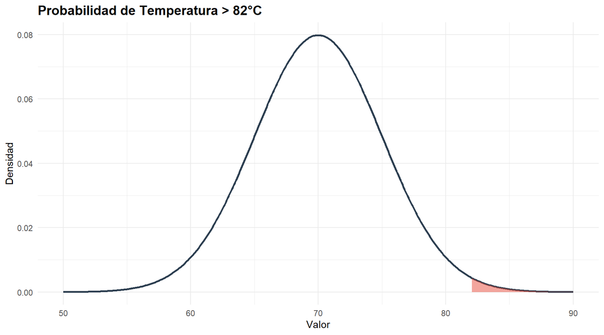

```r
prob_82 <- pnorm(82, mean = mu_1, sd = sigma_1, lower.tail = FALSE)
plot_gaussian(mu_1, sigma_1, lower = 82, title = "Probabilidad de Temperatura > 82°C")
```

La probabilidad de que la temperatura supere los 82°C es de **0.0082**. Dado que 82 está dentro del rango normal, no se dispararía una alerta inmediata de fuera de rango ($\pm 3\sigma$).

### (c) Porcentaje de anomalías esperado

Según la regla empírica, el 99.7% de los datos cae dentro de $3\sigma$.

```r
porcentaje_anomalo <- (1 - 0.997) * 100
```

Se espera un **0.3%** de anomalías bajo condiciones normales.

## Ejercicio 2: Clasificación en modelos de crédito

**Contexto:** Las puntuaciones crediticias siguen una distribución $N(650, 80)$. Un puntaje < 550 se considera alto riesgo.

### (a) Estandarización (Puntuación Z)

Para $x = 550$: $Z = \frac{x - \mu}{\sigma}$

```r
mu_2 <- 650
sigma_2 <- 80
Z_550 <- (550 - mu_2) / sigma_2
```

La puntuación Z para 550 es **-1.25**.

### (b) Proporción de alto riesgo

Calculamos $P(X < 550)$.

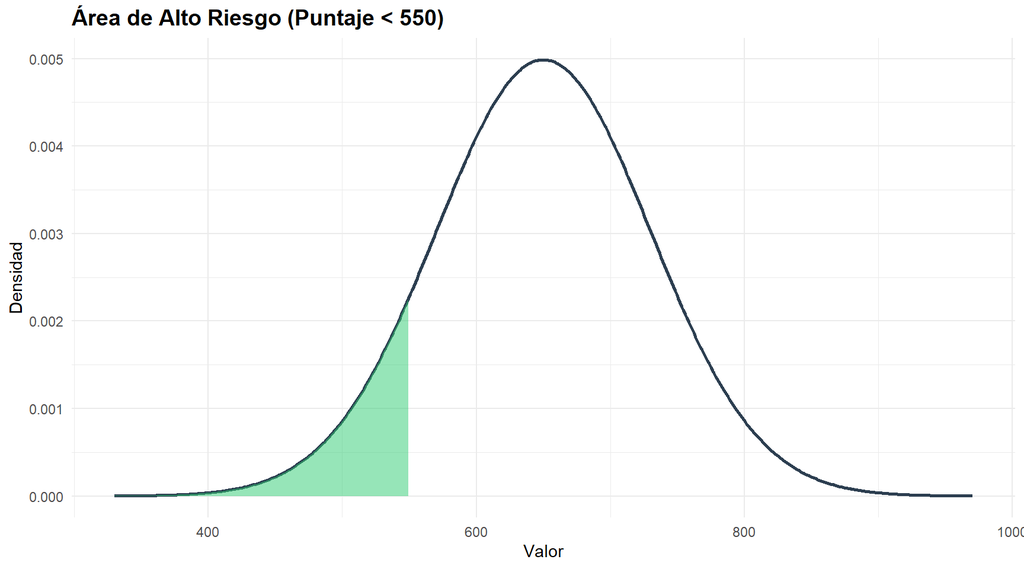

```r
prob_alto_riesgo <- pnorm(550, mean = mu_2, sd = sigma_2)
plot_gaussian(mu_2, sigma_2, upper = 550, title = "Área de Alto Riesgo (Puntaje < 550)")
```

La proporción de la cartera en alto riesgo es **10.56%**.

### (c) Ajuste de umbral para el 5%

Buscamos el valor $x$ tal que $P(X < x) = 0.05$.

```r
umbral_5pct <- qnorm(0.05, mean = mu_2, sd = sigma_2)
```

El nuevo umbral para limitar el alto riesgo al 5% es **518.41**.

## Ejercicio 3: Control de calidad en predicciones

**Contexto:** Los errores de predicción siguen una distribución $N(0, 200)$.

### (a) Probabilidad de error inaceptable ($|e| > 400$)

Calculamos $P(X < -400) + P(X > 400)$.

```r
mu_3 <- 0
sigma_3 <- 200
prob_inaceptable <- 2 * pnorm(-400, mean = mu_3, sd = sigma_3)
```

La probabilidad de un error inaceptable es **0.0455**.

### (b) Errores esperados en 30 días

```r
errores_esperados <- 30 * prob_inaceptable
```

Se esperan aproximadamente **1.37** errores inaceptables al mes.

### (c) Mejora con reducción de varianza

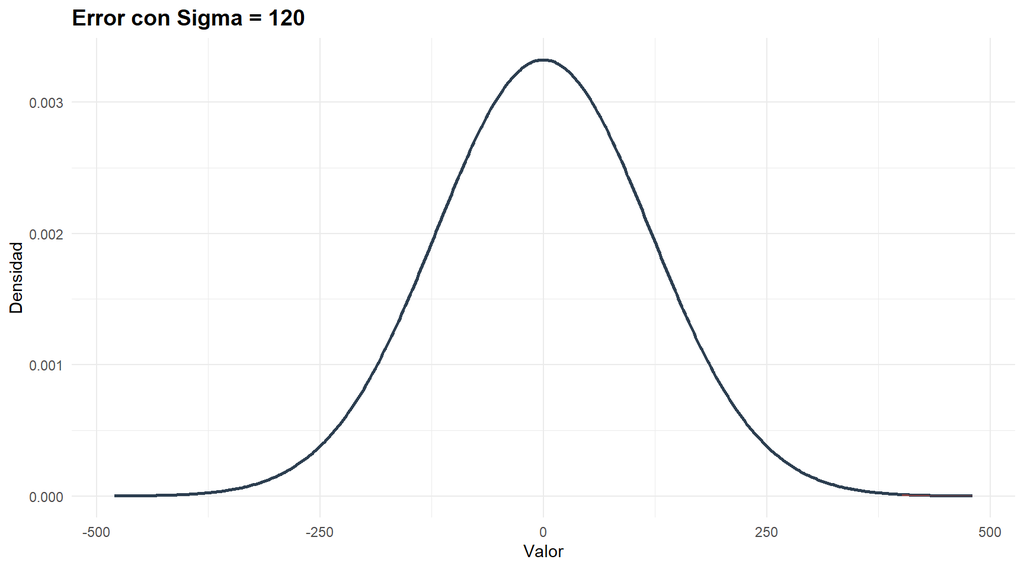

```r
sigma_3_nueva <- 120
prob_inaceptable_nueva <- 2 * pnorm(-400, mean = mu_3, sd = sigma_3_nueva)
plot_gaussian(mu_3, sigma_3_nueva, lower = 400, title = "Error con Sigma = 120")
```

## Ejercicio 4: Muestreo de Usuarios

**Contexto:** Edad de usuarios en una plataforma $N(34, 9)$.

### (a) Rango de edad (25 a 43 años)

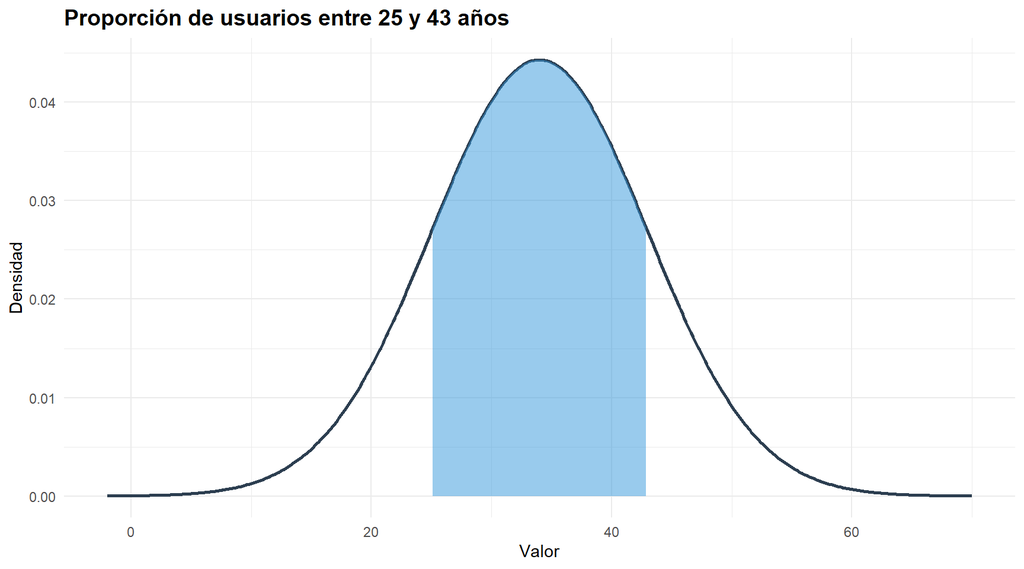

```r
mu_4 <- 34
sigma_4 <- 9
prob_25_43 <- pnorm(43, mean = mu_4, sd = sigma_4) - pnorm(25, mean = mu_4, sd = sigma_4)
plot_gaussian(mu_4, sigma_4, lower = 25, upper = 43, title = "Proporción de usuarios entre 25 y 43 años")
```

El **68.27%** de los usuarios se encuentra en este rango.

### (b) Percentil 90 (10% más mayor)

```r
edad_10pct_superior <- qnorm(0.90, mean = mu_4, sd = sigma_4)
```

El 10% de los usuarios de mayor edad supera los **45.5** años.

## Ejercicio 5: Tiempos de respuesta (SLA)

**Contexto:** Tiempo de respuesta $N(120, 25)$ ms.

### (a) Probabilidad de evento raro ($X > 170$ ms)

```r
mu_5 <- 120
sigma_5 <- 25
prob_170 <- pnorm(170, mean = mu_5, sd = sigma_5, lower.tail = FALSE)
```

La probabilidad es **0.0228** (~2.2%). Se considera un evento poco frecuente.

### (b) Definición de SLA (99%)

```r
T_99 <- qnorm(0.99, mean = mu_5, sd = sigma_5)
```

Para cubrir el 99% de las peticiones, el SLA debe ser de **178.16 ms**.

### (c) Impacto de duplicar la varianza en tráfico pico

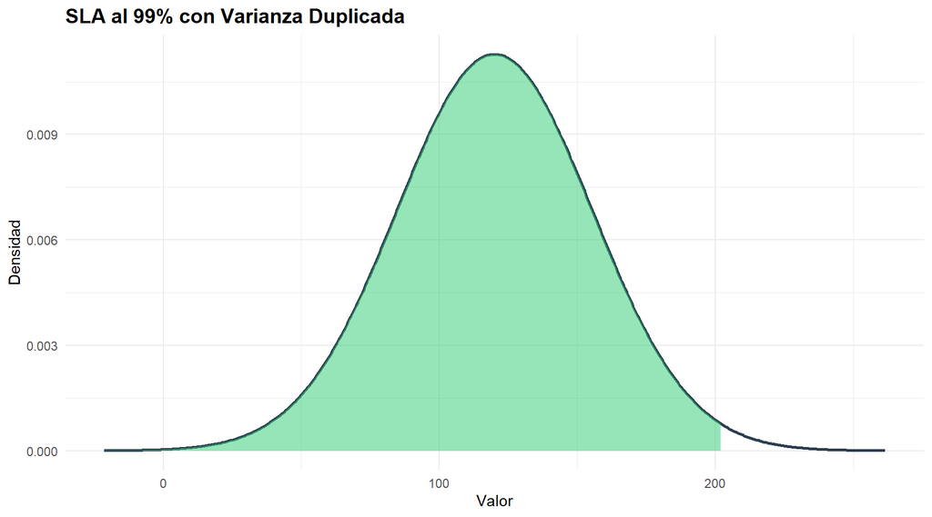

```r
nueva_sigma <- sqrt(2 * (sigma_5^2))
T_99_pico <- qnorm(0.99, mean = mu_5, sd = nueva_sigma)
plot_gaussian(mu_5, nueva_sigma, upper = T_99_pico, title = "SLA al 99% con Varianza Duplicada")
```

En hora pico, el valor T necesario sube a **202.25 ms**.